# The Sentiment on International Women’s Day 2019, Bhutan

January 29, 2020

# Introduction

## Which media house published the longest article?

Of the six articles, DAILYBHUTAN had the maximum number of sentences and words. TheBhutanese, on the other hand had the least number of sentences and words. Although the article by DAILYBHUTAN was compiled from the news published by BBS, the length of the article in terms of both number of sentences and words were longer than BBS. The number of unique words in Pressreader was almost equal the DAILYBHUTAN although the length of the article was slightly longer for DAILYBHUTAN.

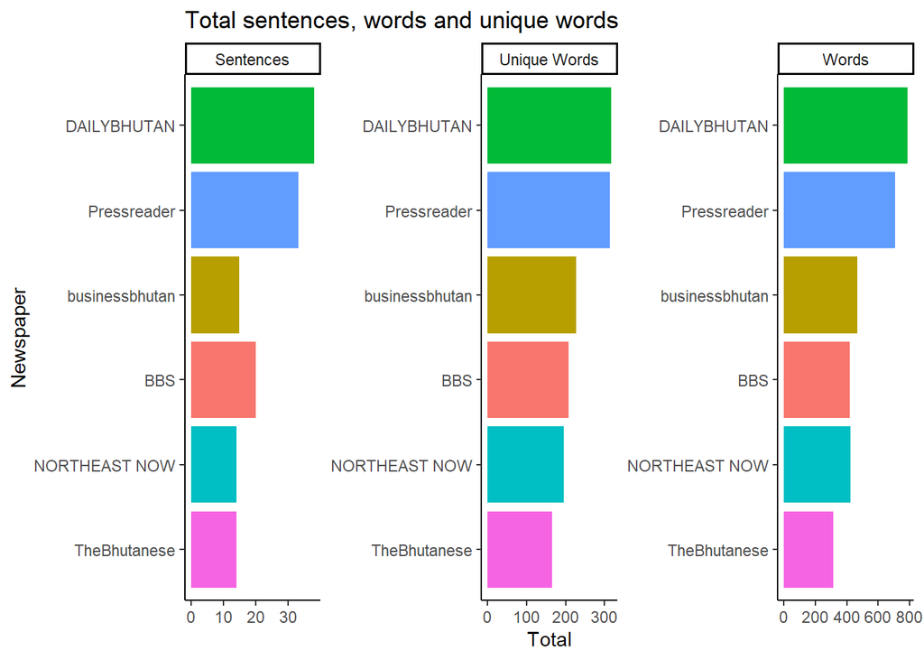

## How easy is it to read the articles?

Readability test of the articles was conducted using [Flesch-Kincaid!](https://en.wikipedia.org/wiki/Flesch%E2%80%93Kincaid_readability_tests), which is a widely used readability test. The test is designed to indicate how difficult a passage in English is to read based on the total number of words and sentences. The score is computed based on the number of words per sentence and the number of syllables per word. Longer the sentences, or higher number of syllables in a word, or both, the article is considered more difficult to read. The resulting score is a number that corresponds to U.S. school grade levels. It is important to note here that the score is not based on the content of the sentence. The readability test show that a person with Class X can read the article pubished in BBS website and DAILYBHUTAN. To read the Pressreader and TheBhutanese, an individual need to have attained at least Class XI or XII. In order to read NORTHEAST NOW and businessbhutan, one should have at least completed a U.S grade level of Bachelors degree. The opening sentences from BBS and NORTHEAST NOW was compared to see the differences in their language and words.

**BBS** *To celebrate the International Women’s Day, the national airlines, Drukair operated its first ever all-female crew flight from Paro to Bangkok via Bagdora today.*

**NORTHEAST NOW** *Along with the rest of the world Drukair, Royal Bhutan Airlines celebrated the International Women’s Day in an unique way by operating an all-female crew flight.*

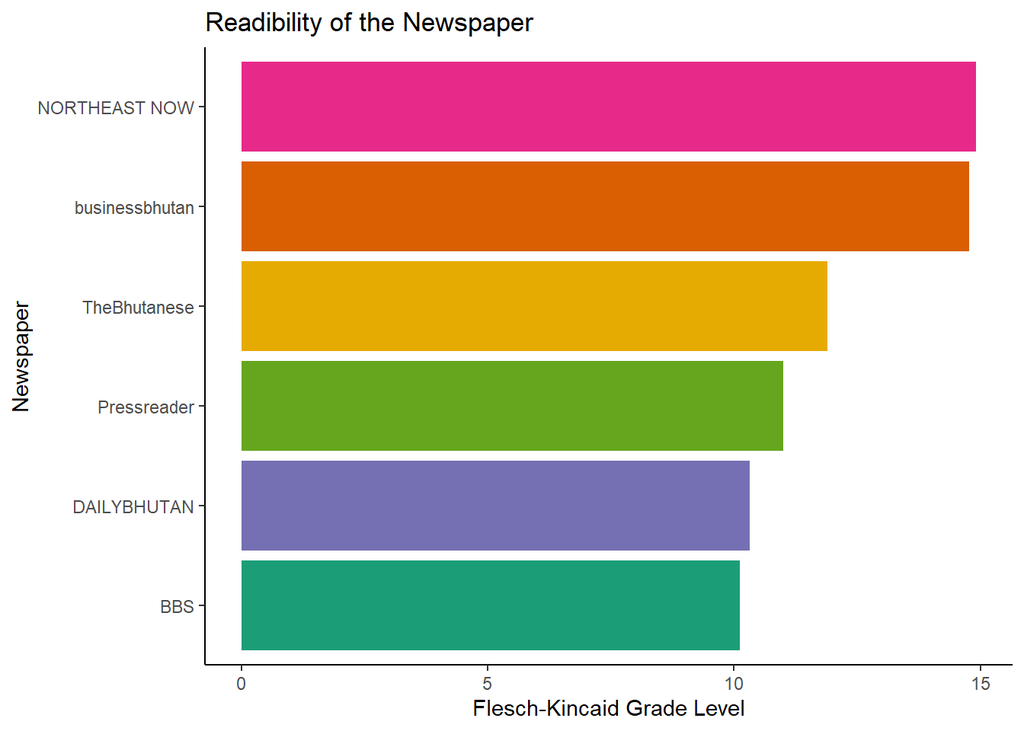

## What sentiment were expressed in the articles?

Sentiment analysis of the article was conducted to see what type of affective emotions were expressed in the articles. Sentiment analysis involves systematically identifying, extracting, quantifying, and studying affective states and subjective information in the article. According to Julia Silge and David Robinson, “when human readers approach a text, we use our understanding of the emotional intent of words to infer whether a section of text is positive or negative, or perhaps characterized by some other more nuanced emotion like surprise or disgust.” There are numerous approach to conducting the analysis such as classfying the sentiment of the text based on sentences or the particular word. The classification of words into different sentiment is based on dictionaries that are available for evaluating the opinion or emotion in text. There are programmes that is capable of classifying Emojis and Emoticons as well. For the purpose of sentiment analysis in this article, sentiment associated to words were considered. There are many sentiment dictionaries or lexicon available for sentiment analysis. The **nrc** lexicon by [Saif Mohammad and Peter Turney!](https://saifmohammad.com/WebPages/NRC-Emotion-Lexicon.htm) was used in this article. The **nrc** lexicon categorizes words into categories of positive, negative, anger, anticipation, disgust, fear, joy, sadness, surprise, and trust emotions. The analysis show that the the number of positive emotions, trust, anticipation and joy are higher compared to other negative emotions. The emotion on particular event was positive one with trust, joy, and anticipation. There were few negative sentiments as well. On closer examination, words such as ‘flying’ and ‘discrimination’ were classified as ‘fear’ and ‘negative’. To understand the sentiment further, it would be important to see which words contribute to the different sentiment and understand the cntext of the article.

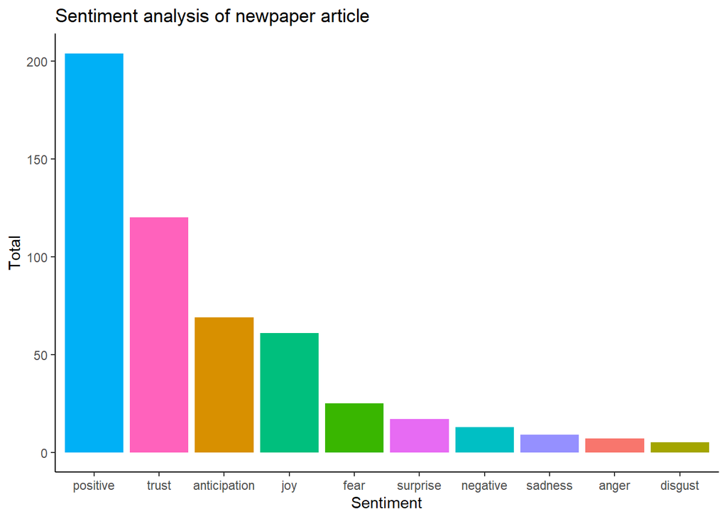

## Who were named in the report?

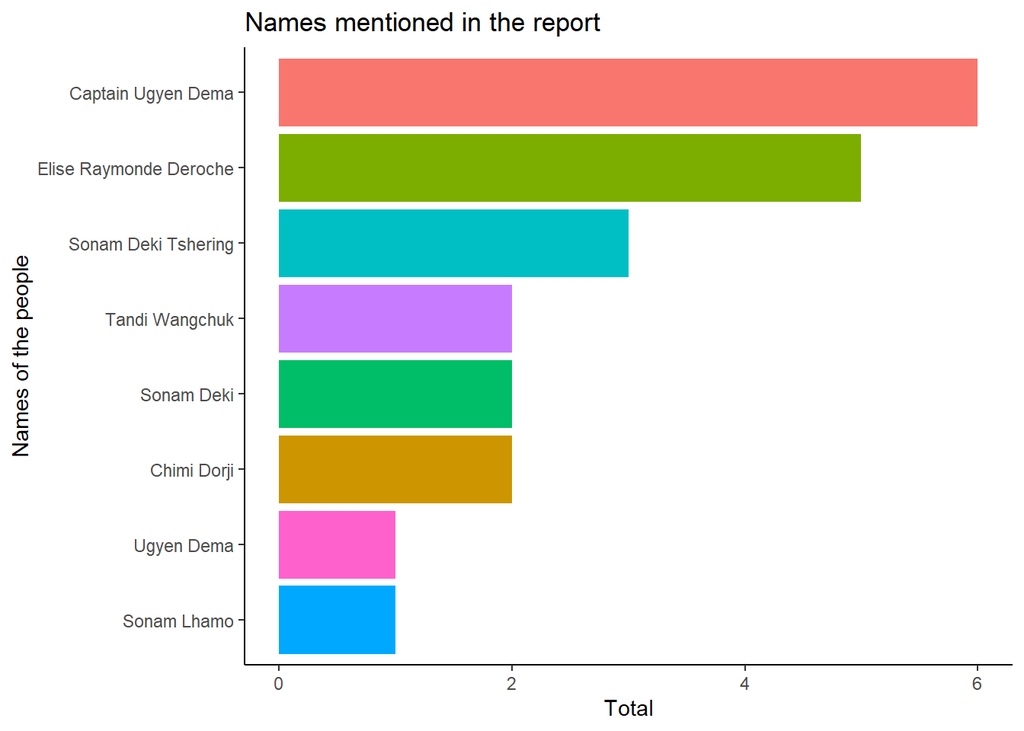

The analysis was limited to six articles from six different media houses. The article from Kuenseonline, which is one of the leading newspaper in Bhutan could not be included as I am not a registered user and do not have the credential to download the article. Similar analysis in different thematic areas may be useful in future for policy, practice and understanding of how public in general view the issues.